# Explore and Summarize Data (Prosper Loan Data)

Ekaterina Kravtchenko

5/20/2018

## Data Exploration

```r
library(tidyverse)
library(magrittr)
library(scales)
data <- read_csv("prosperLoanData.csv") %>% mutate_if(is.character, as.factor)
```

### Data Cleaning

```r
data
```

```
## # A tibble: 113,937 x 81
##    ListingKey          ListingNumber ListingCreationDate CreditGrade  Term
##    <fct>                       <int> <dttm>              <fct>       <int>
##  1 102133976686814541…        193129 2007-08-26 19:09:29 C              36
##  2 10273602499503308B…       1209647 2014-02-27 08:28:07 <NA>           36
##  3 0EE933782585103286…         81716 2007-01-05 15:00:47 HR             36
##  4 0EF535600248271529…        658116 2012-10-22 11:02:35 <NA>           36
##  5 0F023589499656230C…        909464 2013-09-14 18:38:39 <NA>           36
##  6 0F0535973482419938…       1074836 2013-12-14 08:26:37 <NA>           60
##  7 0F0A3576754255009D…        750899 2013-04-12 09:52:56 <NA>           36
##  8 0F1035772717087366…        768193 2013-05-05 06:49:27 <NA>           36
##  9 0F043596202561788E…       1023355 2013-12-02 10:43:39 <NA>           36
## 10 0F043596202561788E…       1023355 2013-12-02 10:43:39 <NA>           36
## # ... with 113,927 more rows, and 76 more variables: LoanStatus <fct>,
## #   ClosedDate <dttm>, BorrowerAPR <dbl>, BorrowerRate <dbl>,
## #   LenderYield <dbl>, EstimatedEffectiveYield <dbl>, EstimatedLoss <dbl>,
## #   EstimatedReturn <dbl>, `ProsperRating (numeric)` <int>, `ProsperRating
## #   (Alpha)` <fct>, ProsperScore <dbl>, `ListingCategory (numeric)` <int>,
## #   BorrowerState <fct>, Occupation <fct>, EmploymentStatus <fct>,
## #   EmploymentStatusDuration <int>, IsBorrowerHomeowner <fct>,
## #   CurrentlyInGroup <fct>, GroupKey <fct>, DateCreditPulled <dttm>,
## #   CreditScoreRangeLower <int>, CreditScoreRangeUpper <int>,
## #   FirstRecordedCreditLine <dttm>, CurrentCreditLines <int>,
## #   OpenCreditLines <int>, TotalCreditLinespast7years <int>,
## #   OpenRevolvingAccounts <int>, OpenRevolvingMonthlyPayment <dbl>,
## #   InquiriesLast6Months <int>, TotalInquiries <dbl>,
## #   CurrentDelinquencies <int>, AmountDelinquent <dbl>,
## #   DelinquenciesLast7Years <int>, PublicRecordsLast10Years <int>,
## #   PublicRecordsLast12Months <int>, RevolvingCreditBalance <dbl>,
## #   BankcardUtilization <dbl>, AvailableBankcardCredit <dbl>,
## #   TotalTrades <dbl>, `TradesNeverDelinquent (percentage)` <dbl>,
## #   TradesOpenedLast6Months <dbl>, DebtToIncomeRatio <dbl>,
## #   IncomeRange <fct>, IncomeVerifiable <fct>, StatedMonthlyIncome <dbl>,
## #   LoanKey <fct>, TotalProsperLoans <int>,
## #   TotalProsperPaymentsBilled <int>, OnTimeProsperPayments <int>,
## #   ProsperPaymentsLessThanOneMonthLate <int>,
## #   ProsperPaymentsOneMonthPlusLate <int>, ProsperPrincipalBorrowed <dbl>,
## #   ProsperPrincipalOutstanding <dbl>, ScorexChangeAtTimeOfListing <int>,
## #   LoanCurrentDaysDelinquent <int>, LoanFirstDefaultedCycleNumber <int>,
## #   LoanMonthsSinceOrigination <int>, LoanNumber <int>,
## #   LoanOriginalAmount <int>, LoanOriginationDate <dttm>,
## #   LoanOriginationQuarter <fct>, MemberKey <fct>,
## #   MonthlyLoanPayment <dbl>, LP_CustomerPayments <dbl>,
## #   LP_CustomerPrincipalPayments <dbl>, LP_InterestandFees <dbl>,
## #   LP_ServiceFees <dbl>, LP_CollectionFees <dbl>,
## #   LP_GrossPrincipalLoss <dbl>, LP_NetPrincipalLoss <dbl>,
## #   LP_NonPrincipalRecoverypayments <dbl>, PercentFunded <dbl>,
## #   Recommendations <int>, InvestmentFromFriendsCount <int>,
## #   InvestmentFromFriendsAmount <dbl>, Investors <int>
```

```r
str(data)
```

```
## Classes 'tbl_df', 'tbl' and 'data.frame':    113937 obs. of  81 variables:
##  $ ListingKey                         : Factor w/ 113066 levels "00003546482094282EF90E5",..: 7180 7193 6647 6669 6686 6689 6699 6706 6687 6687 ...
##  $ ListingNumber                      : int  193129 1209647 81716 658116 909464 1074836 750899 768193 1023355 1023355 ...
##  $ ListingCreationDate                : POSIXct, format: "2007-08-26 19:09:29" "2014-02-27 08:28:07" ...
##  $ CreditGrade                        : Factor w/ 8 levels "A","AA","B","C",..: 4 NA 7 NA NA NA NA NA NA NA ...
##  $ Term                               : int  36 36 36 36 36 60 36 36 36 36 ...
##  $ LoanStatus                         : Factor w/ 12 levels "Cancelled","Chargedoff",..: 3 4 3 4 4 4 4 4 4 4 ...
##  $ ClosedDate                         : POSIXct, format: "2009-08-14" NA ...
##  $ BorrowerAPR                        : num  0.165 0.12 0.283 0.125 0.246 ...
##  $ BorrowerRate                       : num  0.158 0.092 0.275 0.0974 0.2085 ...
##  $ LenderYield                        : num  0.138 0.082 0.24 0.0874 0.1985 ...
##  $ EstimatedEffectiveYield            : num  NA 0.0796 NA 0.0849 0.1832 ...
##  $ EstimatedLoss                      : num  NA 0.0249 NA 0.0249 0.0925 ...
##  $ EstimatedReturn                    : num  NA 0.0547 NA 0.06 0.0907 ...
##  $ ProsperRating (numeric)            : int  NA 6 NA 6 3 5 2 4 7 7 ...
```

[output cut: 67 more lines]

The first thing I notice is that there are several date columns which should be formatted as such, and several boolean (True/False) columns. I also want to order the levels in some of the factor columns, as they are inherently ordered (`CreditGrade`, `ProsperRating.alpha`, `IncomeRange`, `LoanOriginationQuarter`).

```r
data %<>%
  mutate_at(c("ListingCreationDate","ClosedDate","DateCreditPulled","FirstRecordedCreditLine","LoanOriginationDate"), as.Date) %>%
  mutate_at(c("IsBorrowerHomeowner","CurrentlyInGroup","IncomeVerifiable"), as.logical) %>%
  rename_all(~sub(" (numeric)", ".num", ., fixed=TRUE)) %>%
  rename_all(~sub(" (Alpha)", ".alpha", ., fixed=TRUE)) %>%
  rename_all(~sub(" (percentage)", ".per", ., fixed=TRUE))

data$CreditGrade <- ordered(data$CreditGrade, c("NC","HR","E","D","C","B","A","AA"))
data$ProsperRating.alpha <- ordered(data$ProsperRating.alpha, c("NC","HR","E","D","C","B","A","AA"))
data$IncomeRange <- ordered(data$IncomeRange, c("Not displayed","Not employed","$0","$1-24,999","$25,000-49,999","$50,000-74,999","$75,000-99,999","$100,000+"))
data$LoanOriginationQuarter <- ordered(data$LoanOriginationQuarter, c("Q1 2006", "Q2 2006", "Q3 2006", "Q4 2006", "Q1 2007", "Q2 2007", "Q3 2007", "Q4 2007", "Q1 2008", "Q2 2008", "Q3 2008", "Q4 2008", "Q1 2009", "Q2 2009", "Q3 2009", "Q4 2009", "Q1 2010", "Q2 2010", "Q3 2010", "Q4 2010", "Q1 2011", "Q2 2011", "Q3 2011", "Q4 2011", "Q1 2012", "Q2 2012", "Q3 2012", "Q4 2012", "Q1 2013", "Q2 2013", "Q3 2013", "Q4 2013", "Q1 2014", "Q2 2014", "Q3 2014", "Q4 2014"))

str(data)
```

```
## Classes 'tbl_df', 'tbl' and 'data.frame':    113937 obs. of  81 variables:
##  $ ListingKey                         : Factor w/ 113066 levels "00003546482094282EF90E5",..: 7180 7193 6647 6669 6686 6689 6699 6706 6687 6687 ...
##  $ ListingNumber                      : int  193129 1209647 81716 658116 909464 1074836 750899 768193 1023355 1023355 ...
##  $ ListingCreationDate                : Date, format:
```

```
## "2007-08-26" "2014-02-27" ...
##  $ CreditGrade                        : Ord.factor w/ 8 levels "NC"<"HR"<"E"<..: 5 NA 2 NA NA NA NA NA NA NA ...
##  $ Term                               : int  36 36 36 36 36 60 36 36 36 36 ...
##  $ LoanStatus                         : Factor w/ 12 levels "Cancelled","Chargedoff",..: 3 4 3 4 4 4 4 4 4 4 ...
##  $ ClosedDate                         : Date, format: "2009-08-14" NA ...
##  $ BorrowerAPR                        : num  0.165 0.12 0.283 0.125 0.246 ...
##  $ BorrowerRate                       : num  0.158 0.092 0.275 0.0974 0.2085 ...
##  $ LenderYield                        : num  0.138 0.082 0.24 0.0874 0.1985 ...
##  $ EstimatedEffectiveYield            : num  NA 0.0796 NA 0.0849 0.1832 ...
##  $ EstimatedLoss                      : num  NA 0.0249 NA 0.0249 0.0925 ...
##  $ EstimatedReturn                    : num  NA 0.0547 NA 0.06 0.0907 ...
##  $ ProsperRating.num                  : int  NA 6 NA 6 3 5 2 4 7 7 ...
##  $ ProsperRating.alpha                : Ord.factor w/ 8 levels "NC"<"HR"<"E"<..: NA 7 NA 7 4 6 3 5 8 8 ...
##  $ ProsperScore                       : num  NA 7 NA 9 4 10 2 4 9 11 ...
##  $ ListingCategory.num                : int  0 2 0 16 2 1 1 2 7 7 ...
```

[output cut: 64 more lines]

### First Impressions

Now I want to take a look at a summary of the data, to try to figure out what might be going on:

```r
summary(data)
```

```
##                    ListingKey     ListingNumber     ListingCreationDate
##  17A93590655669644DB4C06:     6   Min.   :      4   Min.   :2005-11-09
##  349D3587495831350F0F648:     4   1st Qu.: 400919   1st Qu.:2008-09-19
##  47C1359638497431975670B:     4   Median : 600554   Median :2012-06-16
##  8474358854651984137201C:     4   Mean   : 627886   Mean   :2011-07-08
##  DE8535960513435199406CE:     4   3rd Qu.: 892634   3rd Qu.:2013-09-09
##  04C13599434217079754AEE:     3   Max.   :1255725   Max.   :2014-03-10
##  (Other)                :113912
##   CreditGrade         Term                       LoanStatus
##  C      : 5649   Min.   :12.00   Current              :56576
##  D      : 5153   1st Qu.:36.00   Completed            :38074
##  B      : 4389   Median :36.00   Chargedoff           :11992
##  AA     : 3509   Mean   :40.83   Defaulted            : 5018
##  HR     : 3508   3rd Qu.:36.00   Past Due (1-15 days) :  806
##  (Other): 6745   Max.   :60.00   Past Due (31-60 days):  363
##  NA's   :84984                   (Other)              : 1108
##    ClosedDate          BorrowerAPR       BorrowerRate     LenderYield
##  Min.   :2005-11-25   Min.   :0.00653   Min.   :0.0000   Min.   :-0.0100
##  1st Qu.:2009-07-14   1st Qu.:0.15629   1st Qu.:0.1340   1st Qu.: 0.1242
##  Median :2011-04-05   Median :0.20976   Median :0.1840   Median : 0.1730
##  Mean   :2011-03-07   Mean   :0.21883   Mean   :0.1928   Mean   : 0.1827
##  3rd Qu.:2013-01-30   3rd Qu.:0.28381   3rd Qu.:0.2500   3rd Qu.: 0.2400
##  Max.   :2014-03-10   Max.   :0.51229   Max.   :0.4975   Max.   : 0.4925
##  NA's   :58848        NA's   :25
##  EstimatedEffectiveYield EstimatedLoss   EstimatedReturn
##  Min.   :-0.183          Min.   :0.005   Min.   :-0.183
##  1st Qu.: 0.116          1st Qu.:0.042   1st Qu.: 0.074
##  Median : 0.162          Median :0.072   Median : 0.092
##  Mean   : 0.169          Mean   :0.080   Mean   : 0.096
##  3rd Qu.: 0.224          3rd Qu.:0.112   3rd Qu.: 0.117
##  Max.   : 0.320          Max.   :0.366   Max.   : 0.284
##  NA's   :29084           NA's   :29084   NA's   :29084
##  ProsperRating.num ProsperRating.alpha  ProsperScore   ListingCategory.num
##  Min.   :1.000     C      :18345       Min.   : 1.00   Min.   : 0.000
##  1st Qu.:3.000     B      :15581       1st Qu.: 4.00   1st Qu.: 1.000
##  Median :4.000     A      :14551       Median : 6.00   Median : 1.000
##  Mean   :4.072     D      :14274       Mean   : 5.95   Mean   : 2.774
##  3rd Qu.:5.000     E      : 9795       3rd Qu.: 8.00   3rd Qu.: 3.000
##  Max.   :7.000     (Other):12307       Max.   :11.00   Max.   :20.000
##  NA's   :29084     NA's   :29084       NA's   :29084
```

[output cut: 169 more lines]

```
##  Min.   :    0.00                Min.   :0.7000   Min.   : 0.00000
##  1st Qu.:    0.00                1st Qu.:1.0000   1st Qu.: 0.00000
##  Median :    0.00                Median :1.0000   Median : 0.00000
##  Mean   :   25.14                Mean   :0.9986   Mean   : 0.04803
##  3rd Qu.:    0.00                3rd Qu.:1.0000   3rd Qu.: 0.00000
##  Max.   :21117.90                Max.   :1.0125   Max.   :39.00000
##
##  InvestmentFromFriendsCount InvestmentFromFriendsAmount   Investors
##  Min.   : 0.00000           Min.   :    0.00            Min.   :   1.00
##  1st Qu.: 0.00000           1st Qu.:    0.00            1st Qu.:   2.00
##  Median : 0.00000           Median :    0.00            Median :  44.00
##  Mean   : 0.02346           Mean   :   16.55            Mean   :  80.48
##  3rd Qu.: 0.00000           3rd Qu.:    0.00            3rd Qu.: 115.00
##  Max.   :33.00000           Max.   :25000.00            Max.   :1189.00
##
```

```r
glimpse(data)
```

```
## Observations: 113,937
## Variables: 81
## $ ListingKey                          <fct> 1021339766868145413AB3B, 1...
## $ ListingNumber                       <int> 193129, 1209647, 81716, 65...
## $ ListingCreationDate                 <date> 2007-08-26, 2014-02-27, 2...
## $ CreditGrade                         <ord> C, NA, HR, NA, NA, NA, NA,...
## $ Term                                <int> 36, 36, 36, 36, 36, 60, 36...
## $ LoanStatus                          <fct> Completed, Current, Comple...
## $ ClosedDate                          <date> 2009-08-14, NA, 2009-12-1...
## $ BorrowerAPR                         <dbl> 0.16516, 0.12016, 0.28269,...
## $ BorrowerRate                        <dbl> 0.1580, 0.0920, 0.2750, 0....
## $ LenderYield                         <dbl> 0.1380, 0.0820, 0.2400, 0....
## $ EstimatedEffectiveYield             <dbl> NA, 0.07960, NA, 0.08490, ...
## $ EstimatedLoss                       <dbl> NA, 0.0249, NA, 0.0249, 0....
## $ EstimatedReturn                     <dbl> NA, 0.05470, NA, 0.06000, ...
```

[output cut: 68 more lines]

I first see that there’s a lot of missing data in many of the columns - it’s not clear to me immediately whether this indicates that the data for those rows is truly missing (but theoretically could have been gathered), or if the information in those columns was simply not applicable to those rows. I will sort this out as I move through the data.

The factors of most interest to a bank, I assume, might be (for example) `LoanStatus`, `LenderYield`, `EstimatedEffectiveYield`, `EstimatedLoss`, `EstimatedReturn`, `CurrentDelinquencies`, `AmountDelinquent`, `OnTimeProsperPayments`, `LoanCurrentDaysDelinquent`, `LP_GrossPrincipalLoss`, and `LP_NetPrincipalLoss`. Since the primary concern of a business is profit, these seem most indicative of how much the bank might profit from any particular customer. What the bank should care about, overall, is the ability to predict whether (or to what degree) a given (current or future) customer will be profitable.

On the other hand, the factors I intuitively expect might be predictive of profit are the following (for example): `CreditGrade`, `Occupation`, `EmploymentStatus`, `EmploymentStatusDuration`, `IsBorrowerHomeowner`, `FirstRecordedCreditLine`, `OpenRevolvingAccounts`, `InquiriesLast6Months`, `RevolvingCreditBalance`, `BankcardUtilization`, `TotalTrades`, `DebtToIncomeRatio`, `IncomeRange`, `IncomeVerifiable`, `TotalProsperLoans`, and `LoanOriginationQuarter`.

## Predictive Value

At this point, I want to take a look at how predictive the above background or demographic factors are of factors most closely related to profit. First, I will plot this.

### Loan Status vs. Credit Grade

For `LoanStatus`, as this is not a quantitative or clearly ordered factor, it may make sense to group some of the levels. I therefore group all `Past Due` levels together, and order the levels loosely in terms of ‘goodness’ - assuming that being on time, or having paid off the loan, is ‘good,’ and that having defaulted, or having the loan charged off, is ‘bad.’ I then plot `LoanStatus` by `CreditGrade`, to see if there are any obvious patterns on how likely one is to have a particular loan status, given a particular credit grade.

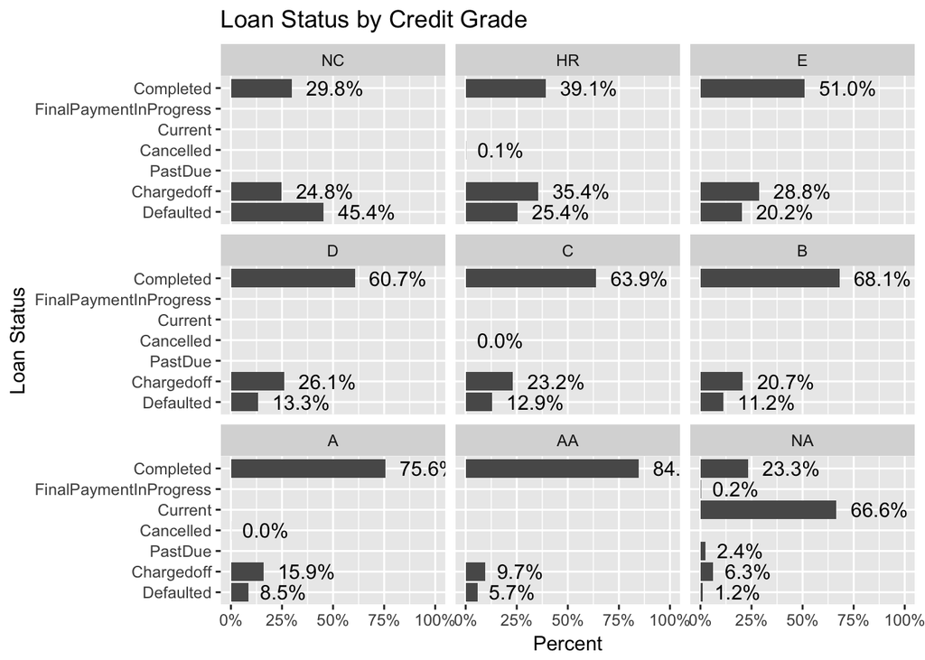

What I see here is that the higher the credit score, in general, the greater the likelihood that the loan has been paid off, and the lower the likelihood that it has been charged off or defaulted. Things get a bit more complicated with the `NA` category - these customers are all over the place, and while most are current, and a sizeable number have paid off their loans, there are also a number of customers who are past due, have defaulted, or have had their loan charged off. This overall picture suggests to me that the bank assigns credit grades only after a loan has been paid off, or otherwise ‘ended.’ There is no way to predict based on credit grades, for existing customers in this database, whether a particular loan will be paid off (or otherwise), but it is likely that a customer with a higher credit grade will be more likely to pay off a loan in the future.

At this point, I want to take a closer look at the `NA` catetory.

```r
data %>%
  group_by(CreditGrade) %>%
  summarize_if(is.numeric, mean, na.rm=TRUE)
```

```
## # A tibble: 9 x 62
##   CreditGrade ListingNumber  Term BorrowerAPR BorrowerRate LenderYield
##   <ord>               <dbl> <dbl>       <dbl>        <dbl>       <dbl>
## 1 NC                  50244  36.0       0.235       0.222       0.209
## 2 HR                 149981  36.0       0.271       0.256       0.242
## 3 E                  158874  36.0       0.271       0.256       0.243
## 4 D                  202726  36.0       0.226       0.212       0.201
## 5 C                  216353  36.0       0.193       0.180       0.169
## 6 B                  225601  36.0       0.164       0.154       0.143
## 7 A                  223024  36.0       0.136       0.125       0.117
## 8 AA                 221444  36.0       0.106       0.0981      0.0923
## 9 <NA>               773208  42.5       0.227       0.196       0.186
## # ... with 56 more variables: EstimatedEffectiveYield <dbl>,
## #   EstimatedLoss <dbl>, EstimatedReturn <dbl>, ProsperRating.num <dbl>,
## #   ProsperScore <dbl>, ListingCategory.num <dbl>,
## #   EmploymentStatusDuration <dbl>, CreditScoreRangeLower <dbl>,
## #   CreditScoreRangeUpper <dbl>, CurrentCreditLines <dbl>,
## #   OpenCreditLines <dbl>, TotalCreditLinespast7years <dbl>,
## #   OpenRevolvingAccounts <dbl>, OpenRevolvingMonthlyPayment <dbl>,
## #   InquiriesLast6Months <dbl>, TotalInquiries <dbl>,
## #   CurrentDelinquencies <dbl>, AmountDelinquent <dbl>,
## #   DelinquenciesLast7Years <dbl>, PublicRecordsLast10Years <dbl>,
## #   PublicRecordsLast12Months <dbl>, RevolvingCreditBalance <dbl>,
## #   BankcardUtilization <dbl>, AvailableBankcardCredit <dbl>,
## #   TotalTrades <dbl>, TradesNeverDelinquent.per <dbl>,
## #   TradesOpenedLast6Months <dbl>, DebtToIncomeRatio <dbl>,
## #   StatedMonthlyIncome <dbl>, TotalProsperLoans <dbl>,
## #   TotalProsperPaymentsBilled <dbl>, OnTimeProsperPayments <dbl>,
## #   ProsperPaymentsLessThanOneMonthLate <dbl>,
## #   ProsperPaymentsOneMonthPlusLate <dbl>, ProsperPrincipalBorrowed <dbl>,
## #   ProsperPrincipalOutstanding <dbl>, ScorexChangeAtTimeOfListing <dbl>,
## #   LoanCurrentDaysDelinquent <dbl>, LoanFirstDefaultedCycleNumber <dbl>,
## #   LoanMonthsSinceOrigination <dbl>, LoanNumber <dbl>,
## #   LoanOriginalAmount <dbl>, MonthlyLoanPayment <dbl>,
## #   LP_CustomerPayments <dbl>, LP_CustomerPrincipalPayments <dbl>,
## #   LP_InterestandFees <dbl>, LP_ServiceFees <dbl>,
## #   LP_CollectionFees <dbl>, LP_GrossPrincipalLoss <dbl>,
## #   LP_NetPrincipalLoss <dbl>, LP_NonPrincipalRecoverypayments <dbl>,
## #   PercentFunded <dbl>, Recommendations <dbl>,
## #   InvestmentFromFriendsCount <dbl>, InvestmentFromFriendsAmount <dbl>,
## #   Investors <dbl>
```

It is not immediately clear what distinguishes these lenders, and why they have no recorded credit rating. The `NA`s have much higher `ListingNumber`s, a slightly higher `Term`, they actually have the following: `EstimatedEffectiveYield`, `EstimatedLoss`, `EstimatedReturn`, `ProsperRating`, `ProsperScore`. They have a higher `ListingCategory`, a much higher average `EmploymentStatusDuration`, but don’t differ too obviously along other measures. They have lower average `PublicRecordsLast12Months`, significantly more `TotalProsperPaymentsBilled` and `OnTimeProsperPayments`, and a much lower average `LoanCurrentDaysDelinquent`. They have a lower `LoanMonthsSinceOrigination` and a higher `LoanNumber`. They are the only ones less than fully funded (`PercentFunded`). They have relatively little investment from friends (`InvestmentFromFriendsAmount`).

```r
library(lubridate)
data %>%
  group_by(CreditGrade) %>%
  summarize_if(is.Date, min, na.rm=TRUE)
```

```
## # A tibble: 9 x 6
##   CreditGrade ListingCreationDate ClosedDate DateCreditPulled
##   <ord>       <date>              <date>     <date>
## 1 NC          2005-11-20          2006-01-06 2005-11-09
## 2 HR          2005-11-18          2006-01-06 2005-11-18
## 3 E           2005-11-15          2005-11-30 2005-11-09
## 4 D           2005-11-21          2006-05-12 2005-11-21
## 5 C           2005-11-20          2005-11-30 2005-11-16
## 6 B           2005-11-18          2005-11-29 2005-11-18
## 7 A           2005-12-21          2006-03-24 2005-12-20
## 8 AA          2005-11-09          2005-11-25 2005-11-09
## 9 <NA>        2007-06-08          2009-08-27 2008-01-23
## # ... with 2 more variables: FirstRecordedCreditLine <date>,
## #   LoanOriginationDate <date>
```

```r
data %>%
  group_by(CreditGrade) %>%
  summarize_if(is.Date , max, na.rm=TRUE)
```

```
## # A tibble: 9 x 6
##   CreditGrade ListingCreationDate ClosedDate DateCreditPulled
##   <ord>       <date>              <date>     <date>
## 1 NC          2007-02-11          2010-02-22 2007-02-11
## 2 HR          2008-10-11          2012-01-31 2008-10-09
## 3 E           2008-10-09          2012-01-27 2008-10-08
## 4 D           2009-04-30          2012-02-09 2009-04-30
## 5 C           2009-05-04          2012-05-13 2009-05-04
## 6 B           2009-05-02          2012-01-15 2009-04-28
## 7 A           2009-04-30          2012-02-29 2009-04-28
## 8 AA          2009-04-29          2011-12-15 2009-04-28
## 9 <NA>        2014-03-10          2014-03-10 2014-03-10
## # ... with 2 more variables: FirstRecordedCreditLine <date>,
## #   LoanOriginationDate <date>
```

```r
library(skimr)
skim(filter(data,is.na(CreditGrade)))
```

```
## Skim summary statistics
##  n obs: 84984
##  n variables: 81
##
## Variable type: Date
##                 variable missing complete     n        min        max
##               ClosedDate   58848    26136 84984 2009-08-27 2014-03-10
##         DateCreditPulled       0    84984 84984 2008-01-23 2014-03-10
##  FirstRecordedCreditLine       0    84984 84984 1951-01-01 2012-12-22
##      ListingCreationDate       0    84984 84984 2007-06-08 2014-03-10
##      LoanOriginationDate       0    84984 84984 2009-07-20 2014-03-12
##      median n_unique
##  2013-02-20     1452
##  2013-03-28     1702
##  1996-01-05    11096
##  2013-03-27     1799
##  2013-04-08     1166
##
## Variable type: factor
##                variable missing complete     n n_unique
##           BorrowerState       0    84984 84984       48
##             CreditGrade   84984        0 84984        0
##        EmploymentStatus       0    84984 84984        7
##                GroupKey   82934     2050 84984      223
##             IncomeRange       0    84984 84984        7
##              ListingKey       0    84984 84984    84113
##                 LoanKey       0    84984 84984    84113
##  LoanOriginationQuarter       0    84984 84984       19
##              LoanStatus       0    84984 84984       11
##               MemberKey       0    84984 84984    69047
##              Occupation    1333    83651 84984       67
##     ProsperRating.alpha     131    84853 84984        7
##                                      top_counts ordered
##         CA: 10779, NY: 5853, TX: 5652, FL: 5410   FALSE
##                   NA: 84984, NC: 0, HR: 0, E: 0    TRUE
##     Emp: 67322, Ful: 8031, Sel: 4542, Oth: 3806   FALSE
##         NA: 82934, 3D4: 311, 783: 213, 52E: 150   FALSE
##  $50: 25672, $25: 24215, $10: 15221, $75: 14515    TRUE
##                  17A: 6, 349: 4, 47C: 4, 847: 4   FALSE
##                  CB1: 6, 2DE: 4, 9F4: 4, D89: 4   FALSE
```

[output cut: 130 more lines]

```
##   1699.24   -504.41      0        0         0      25000    ▇▁▁▁▁▁▁▁
##    119.07      0         0        0         0       7780.03 ▇▁▁▁▁▁▁▁
##     59.71   -589.95    -72.3    -34.9     -14.28       3.01 ▁▁▁▁▁▁▂▇
##    186.67      0       157.15   251.76    388.28    2251.51 ▇▅▁▁▁▁▁▁
##    425.74      0       156      311       563      13765    ▇▁▁▁▁▁▁▁
##      0.021     0.7       1        1         1          1.01 ▁▁▁▁▁▁▁▇
##   7537.38      0      3750     6400     11700      72499    ▇▃▁▁▁▁▁▁
##   3805.88      0         0     1586.16   4104.43   23450.95 ▇▂▁▁▁▁▁▁
##      2.38      1         4        6         8         11    ▂▃▅▇▃▅▂▂
##  31349.19      0      3822     9321     20334      1e+06    ▇▁▁▁▁▁▁▁
##   8234.51      0      3433.33  5000      7083.33 1750002.92 ▇▁▁▁▁▁▁▁
##      3.83      0         2        3         6         78    ▇▁▁▁▁▁▁▁
##     11.61      1        15       23        31        122    ▅▇▃▁▁▁▁▁
##      0.12      0.08      0.85     0.95      1          1    ▁▁▁▁▁▁▂▇
##      0.99      0         0        0         1         20    ▇▁▁▁▁▁▁▁
```

```r
skim(filter(data,!is.na(CreditGrade)))
```

```
## Skim summary statistics
##  n obs: 28953
##  n variables: 81
##
## Variable type: Date
##                 variable missing complete     n        min        max
##               ClosedDate       0    28953 28953 2005-11-25 2012-05-13
##         DateCreditPulled       0    28953 28953 2005-11-09 2009-05-04
##  FirstRecordedCreditLine     697    28256 28953 1947-08-24 2008-07-01
##      ListingCreationDate       0    28953 28953 2005-11-09 2009-05-04
##      LoanOriginationDate       0    28953 28953 2005-11-15 2009-05-14
##      median n_unique
##  2009-08-14     1968
##  2007-08-31     1004
##  1995-05-31     7593
##  2007-09-06     1006
##  2007-09-19      707
##
## Variable type: factor
##                variable missing complete     n n_unique
##           BorrowerState    5515    23438 28953       50
##             CreditGrade       0    28953 28953        8
##        EmploymentStatus    2255    26698 28953        6
##                GroupKey   17662    11291 28953      680
##             IncomeRange       0    28953 28953        8
##              ListingKey       0    28953 28953    28953
##                 LoanKey       0    28953 28953    28953
##  LoanOriginationQuarter      22    28931 28953       13
##              LoanStatus       0    28953 28953        4
##               MemberKey       0    28953 28953    26410
##              Occupation    2255    26698 28953       66
##     ProsperRating.alpha   28953        0 28953        0
##                                  top_counts ordered
##      NA: 5515, CA: 3938, GA: 1656, IL: 1650   FALSE
##         C: 5649, D: 5153, B: 4389, AA: 3509    TRUE
##  Ful: 18324, Not: 5347, NA: 2255, Sel: 1592   FALSE
##     NA: 17662, 783: 927, 6A3: 619, 3D4: 605   FALSE
##  $25: 7977, Not: 7741, $50: 5378, $1-: 2607    TRUE
##              000: 1, 000: 1, 000: 1, 000: 1   FALSE
##              000: 1, 000: 1, 000: 1, 000: 1   FALSE
```

[output cut: 130 more lines]

```
##   3500.15     -954.55      0       0     1761.51   25000    ▇▁▁▁▁▁▁▁
##    503.86        0         0       0        0      21117.9  ▇▁▁▁▁▁▁▁
##     63.43     -664.87    -76.19  -33.48   -13.12      32.06 ▁▁▁▁▁▁▃▇
##    198.92        0        84.9   154.13   276.29    1130.9  ▇▅▂▁▁▁▁▁
##    492.78        0        35     138      374      14985    ▇▁▁▁▁▁▁▁
##      6.5e-05     1         1       1        1          1.01 ▇▁▁▁▁▁▁▁
##   5401.84     1000      2550    4500     7500      40000    ▇▃▁▁▁▁▁▁
##   3810.23        0         0    2045.6   4193.23   21862.26 ▇▃▁▁▁▁▁▁
##     NA          NA        NA      NA       NA         NA
##  38585.64        0      1189    5198    15580    1435667    ▇▁▁▁▁▁▁▁
##   4456.91        0      2500    3833.33  5750     208333.33 ▇▁▁▁▁▁▁▁
##     10.11        0         3       7       13        379    ▇▁▁▁▁▁▁▁
##     12.49        0        11      18       28        126    ▇▇▃▁▁▁▁▁
##      0.21        0         0.69    0.87     1          1    ▁▁▁▁▂▂▃▇
##      1.4         0         0       1        2         17    ▇▁▁▁▁▁▁▁
```

### How Correlated are Profit Factors?

Here, I quickly want to look at how well-correlated the numerical factors associated with profit are, to see if I need to look at all of them when seeing how predictive demographic factors are of profit.

```r
profit <- c("LenderYield", "EstimatedEffectiveYield", "EstimatedLoss", "EstimatedReturn", "CurrentDelinquencies", "AmountDelinquent", "OnTimeProsperPayments", "LoanCurrentDaysDelinquent", "LP_GrossPrincipalLoss", "LP_NetPrincipalLoss","ProsperRating.num")

library(ggcorrplot)

corr <- cor(data[profit], use = "complete.obs")
head(corr[, 1:6])
```

```
##                         LenderYield EstimatedEffectiveYield EstimatedLoss
## LenderYield              1.00000000              0.78408159    0.90720716
## EstimatedEffectiveYield  0.78408159              1.00000000    0.55364750
## EstimatedLoss            0.90720716              0.55364750    1.00000000
## EstimatedReturn          0.74402334              0.81511126    0.39845421
## CurrentDelinquencies     0.19242845              0.14460520    0.20756045
## AmountDelinquent         0.05830044              0.06102939    0.05691653
##                         EstimatedReturn CurrentDelinquencies
## LenderYield                  0.74402334           0.19242845
## EstimatedEffectiveYield      0.81511126           0.14460520
## EstimatedLoss                0.39845421           0.20756045
## EstimatedReturn              1.00000000           0.09166062
## CurrentDelinquencies         0.09166062           1.00000000
## AmountDelinquent             0.03519824           0.42922477
##                         AmountDelinquent
## LenderYield                   0.05830044
## EstimatedEffectiveYield       0.06102939
## EstimatedLoss                 0.05691653
## EstimatedReturn               0.03519824
## CurrentDelinquencies          0.42922477
## AmountDelinquent              1.00000000
```

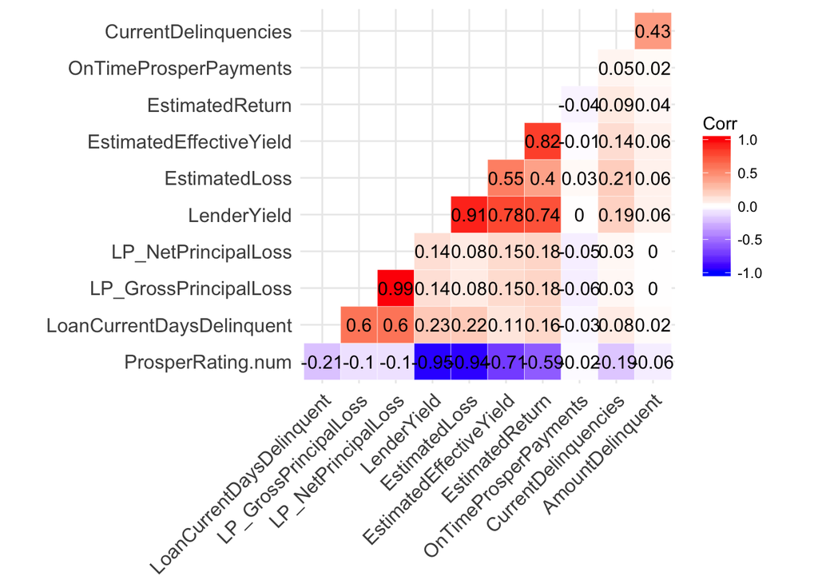

```r
ggcorrplot(corr, hc.order = TRUE, type = "lower",
     outline.col = "white", lab = TRUE)
```

It turns out that most of the potential profit measures are not that well-correlated. Several, however, are well-correlated with each other (poisitively or negatively), and I expect these to likely be better representations of profit (as, if a potential measure of profit correlates with no other potential measures of profit, then it it unlikely to represent profit well, unless it is the single accurate measure of profit in the bunch, which is unlikely).

The profit measures showing the highest correlations with other measures are the following: `EstimatedReturn`, `EstimatedEffectiveYield`, `EstimatedLoss`, `LenderYield`, and `ProsperRating`. It’s likely that the other measures are informative for other, more specific, questions, but at a first glance, it makes sense to look at the most obvious measures of profit. It’s also possible that `LoanStatus`, previously looked at, is also informative, but it has a more indirect relationship to profit (especially given that, as a category, it is inherently in flux).

### Occupation vs. Profit

If credit grades are only assigned once the fate of the loan is known, it may be more useful to look at how predictive pre-existing factors such as `Occupation` are of profit measures.

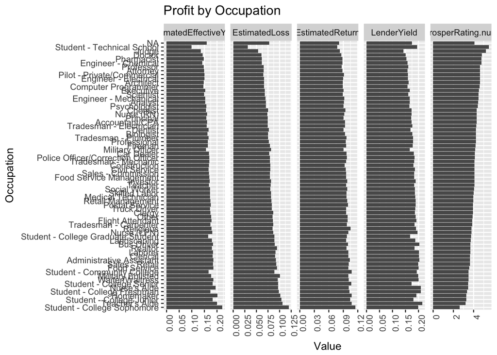

```r
subset <- c("EstimatedReturn", "EstimatedEffectiveYield", "EstimatedLoss", "LenderYield", "ProsperRating.num","Occupation")

plot_data <- data[subset] %>%
  group_by(Occupation) %>%
  summarize_all(funs(mean(., na.rm = TRUE))) %>%
  mutate(Occupation = reorder(Occupation, ProsperRating.num, mean)) %>%
  gather(Measure, Value, -Occupation)

ggplot(plot_data, aes(x = Occupation, y=Value)) +
  geom_bar(stat = "identity") +
  labs(title = "Profit by Occupation") +
  facet_grid(~Measure, scales="free") +
  coord_flip() +
  theme(axis.text.x = element_text(angle = 90, hjust = 1))
```

### Income Range vs. Profit

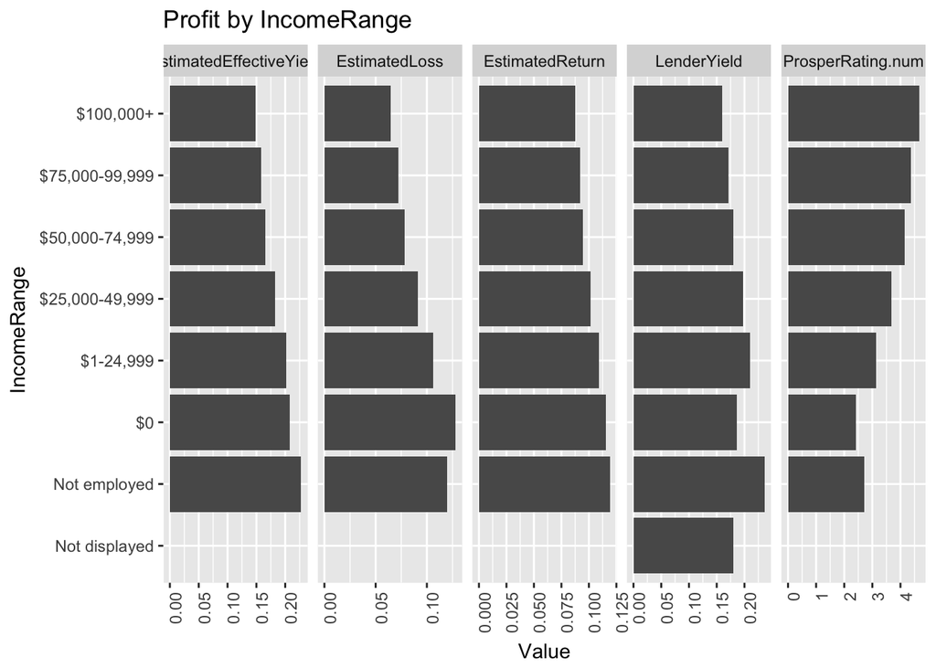

```r
subset <- c("EstimatedReturn", "EstimatedEffectiveYield", "EstimatedLoss", "LenderYield", "ProsperRating.num","IncomeRange")

plot_data <- data[subset] %>%
  group_by(IncomeRange) %>%
  summarize_all(funs(mean(., na.rm = TRUE))) %>%
  gather(Measure, Value, -IncomeRange)

ggplot(plot_data, aes(x = IncomeRange, y=Value)) +
  geom_bar(stat = "identity") +
  labs(title = "Profit by IncomeRange") +
  facet_grid(~Measure, scales="free") +
  coord_flip() +
  theme(axis.text.x = element_text(angle = 90, hjust = 1))
```

### Other vs. Profit

Here, I will look at the relationship between other predictors and profit measures.

`EmploymentStatus`

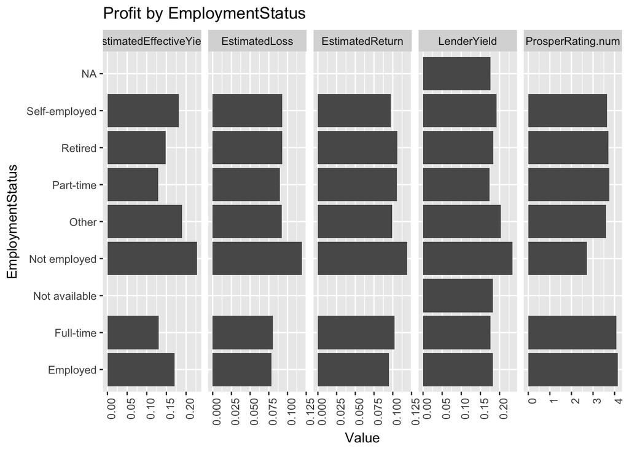

```r
subset <- c("EstimatedReturn", "EstimatedEffectiveYield", "EstimatedLoss", "LenderYield", "ProsperRating.num","EmploymentStatus")

plot_data <- data[subset] %>%
  group_by(EmploymentStatus) %>%
  summarize_all(funs(mean(., na.rm = TRUE))) %>%
  gather(Measure, Value, -EmploymentStatus)

ggplot(plot_data, aes(x = EmploymentStatus, y=Value)) +
  geom_bar(stat = "identity") +
  labs(title = "Profit by EmploymentStatus") +
  facet_grid(~Measure, scales="free") +
  coord_flip() +
  theme(axis.text.x = element_text(angle = 90, hjust = 1))
```

`EmploymentStatusDuration`

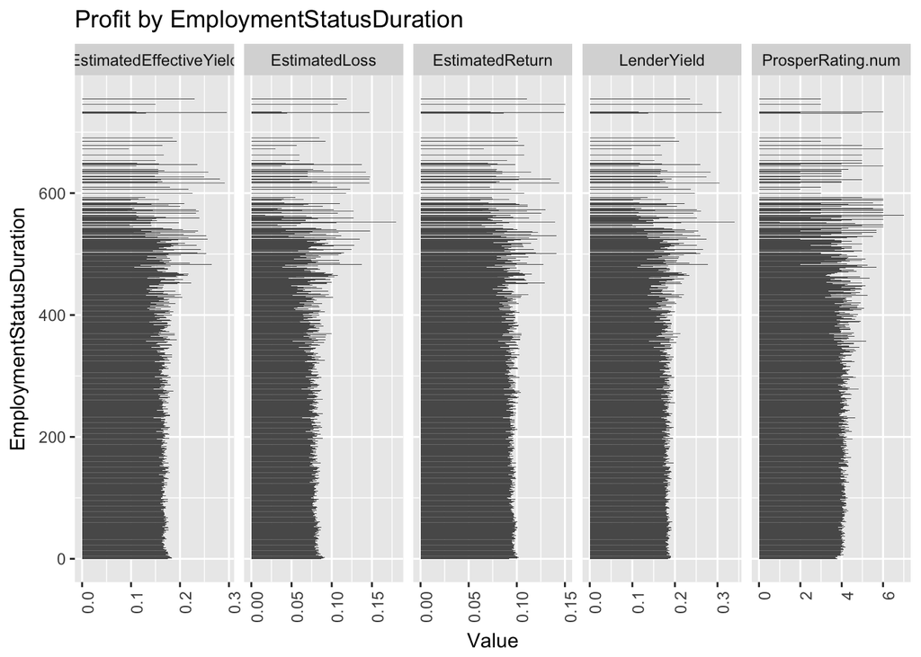

```r
subset <- c("EstimatedReturn", "EstimatedEffectiveYield", "EstimatedLoss", "LenderYield", "ProsperRating.num","EmploymentStatusDuration")

plot_data <- data[subset] %>%
  group_by(EmploymentStatusDuration) %>%
  summarize_all(funs(mean(., na.rm = TRUE))) %>%
  gather(Measure, Value, -EmploymentStatusDuration)

ggplot(plot_data, aes(x = EmploymentStatusDuration, y=Value)) +
  geom_bar(stat = "identity") +
  labs(title = "Profit by EmploymentStatusDuration") +
  facet_grid(~Measure, scales="free") +
  coord_flip() +
  theme(axis.text.x = element_text(angle = 90, hjust = 1))
```

`IsBorrowerHomeowner`

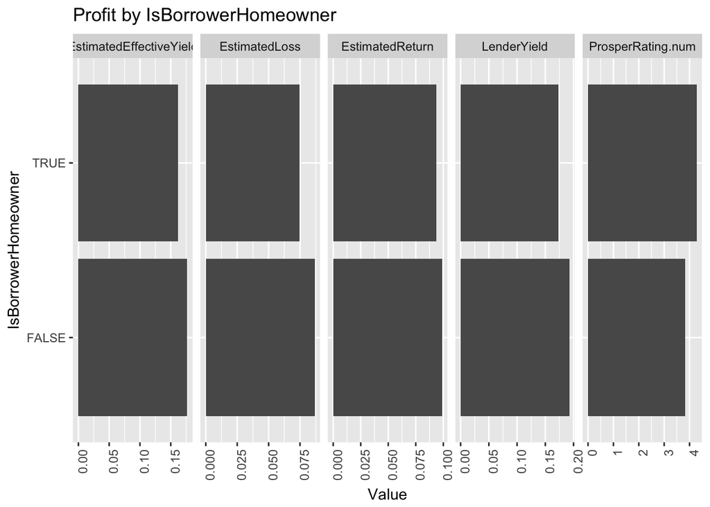

```r
subset <- c("EstimatedReturn", "EstimatedEffectiveYield", "EstimatedLoss", "LenderYield", "ProsperRating.num","IsBorrowerHomeowner")

plot_data <- data[subset] %>%
  group_by(IsBorrowerHomeowner) %>%
  summarize_all(funs(mean(., na.rm = TRUE))) %>%
  gather(Measure, Value, -IsBorrowerHomeowner)

ggplot(plot_data, aes(x = IsBorrowerHomeowner, y=Value)) +
  geom_bar(stat = "identity") +
  labs(title = "Profit by IsBorrowerHomeowner") +
  facet_grid(~Measure, scales="free") +
  coord_flip() +
  theme(axis.text.x = element_text(angle = 90, hjust = 1))
```

`FirstRecordedCreditLine`

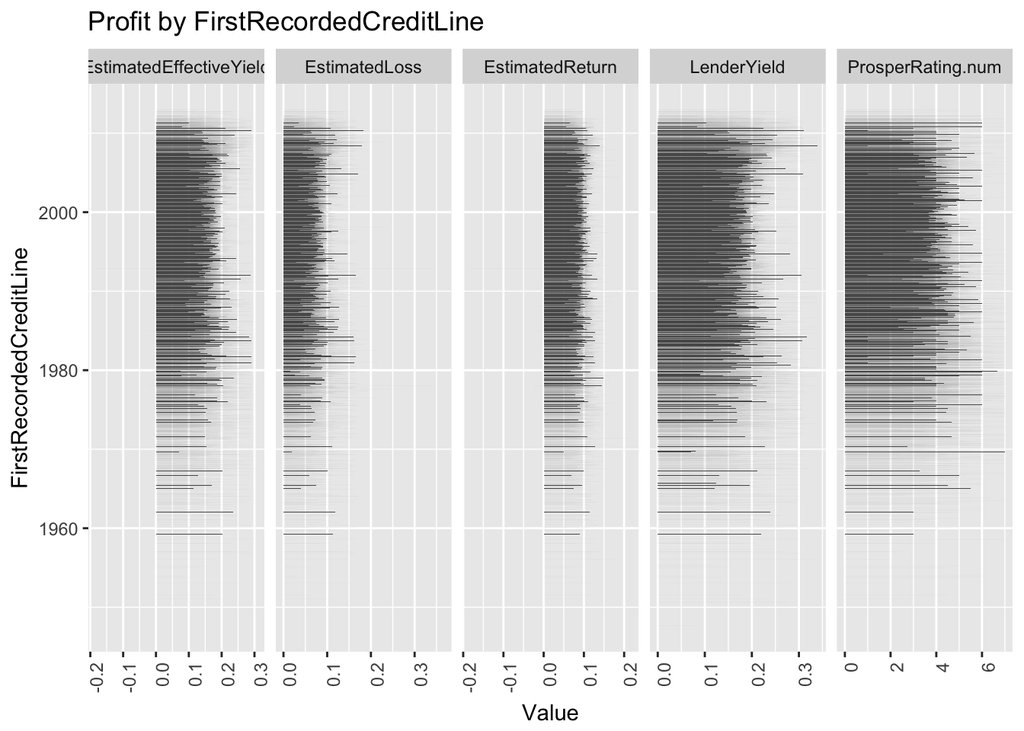

```r
subset <- c("EstimatedReturn", "EstimatedEffectiveYield", "EstimatedLoss", "LenderYield", "ProsperRating.num","FirstRecordedCreditLine")

plot_data <- data[subset] %>%
  group_by(FirstRecordedCreditLine) %>%
  summarize_all(funs(mean(., na.rm = TRUE))) %>%
  gather(Measure, Value, -FirstRecordedCreditLine)

ggplot(plot_data, aes(x = FirstRecordedCreditLine, y=Value)) +
  geom_bar(stat = "identity") +
  labs(title = "Profit by FirstRecordedCreditLine") +
  facet_grid(~Measure, scales="free") +
  coord_flip() +
  theme(axis.text.x = element_text(angle = 90, hjust = 1))
```

`OpenRevolvingAccounts`

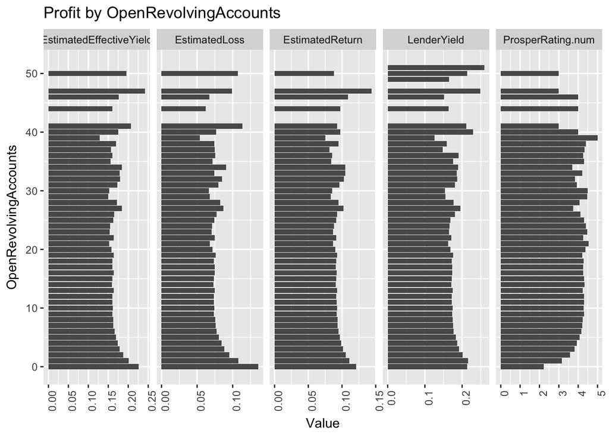

```r
subset <- c("EstimatedReturn", "EstimatedEffectiveYield", "EstimatedLoss", "LenderYield", "ProsperRating.num","OpenRevolvingAccounts")

plot_data <- data[subset] %>%
  group_by(OpenRevolvingAccounts) %>%
  summarize_all(funs(mean(., na.rm = TRUE))) %>%
  gather(Measure, Value, -OpenRevolvingAccounts)

ggplot(plot_data, aes(x = OpenRevolvingAccounts, y=Value)) +
  geom_bar(stat = "identity") +
  labs(title = "Profit by OpenRevolvingAccounts") +
  facet_grid(~Measure, scales="free") +
  coord_flip() +
  theme(axis.text.x = element_text(angle = 90, hjust = 1))
```

`InquiriesLast6Months`

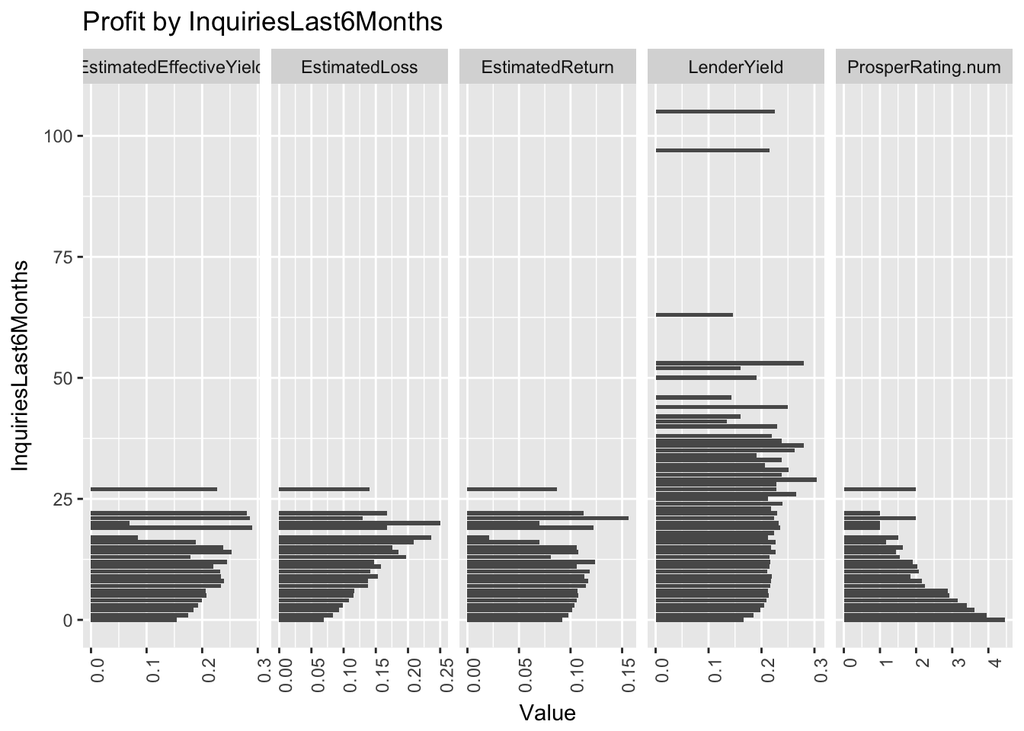

```r
subset <- c("EstimatedReturn", "EstimatedEffectiveYield", "EstimatedLoss", "LenderYield", "ProsperRating.num","InquiriesLast6Months")

plot_data <- data[subset] %>%
  group_by(InquiriesLast6Months) %>%
  summarize_all(funs(mean(., na.rm = TRUE))) %>%
  gather(Measure, Value, -InquiriesLast6Months)

ggplot(plot_data, aes(x = InquiriesLast6Months, y=Value)) +
  geom_bar(stat = "identity") +
  labs(title = "Profit by InquiriesLast6Months") +
  facet_grid(~Measure, scales="free") +
  coord_flip() +
  theme(axis.text.x = element_text(angle = 90, hjust = 1))
```

`RevolvingCreditBalance`

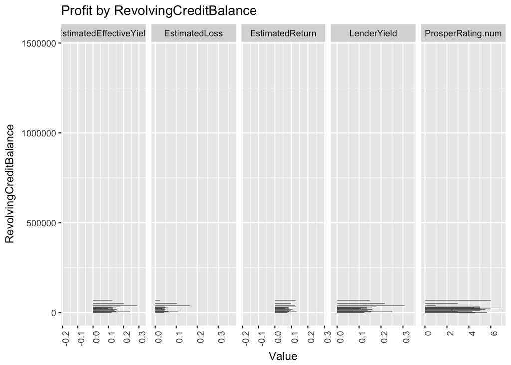

```r
subset <- c("EstimatedReturn", "EstimatedEffectiveYield", "EstimatedLoss", "LenderYield", "ProsperRating.num","RevolvingCreditBalance")

plot_data <- data[subset] %>%
  group_by(RevolvingCreditBalance) %>%
  summarize_all(funs(mean(., na.rm = TRUE))) %>%
  gather(Measure, Value, -RevolvingCreditBalance)

ggplot(plot_data, aes(x = RevolvingCreditBalance, y=Value)) +
  geom_bar(stat = "identity") +
  labs(title = "Profit by RevolvingCreditBalance") +
  facet_grid(~Measure, scales="free") +
  coord_flip() +
  theme(axis.text.x = element_text(angle = 90, hjust = 1))
```

`BankcardUtilization`

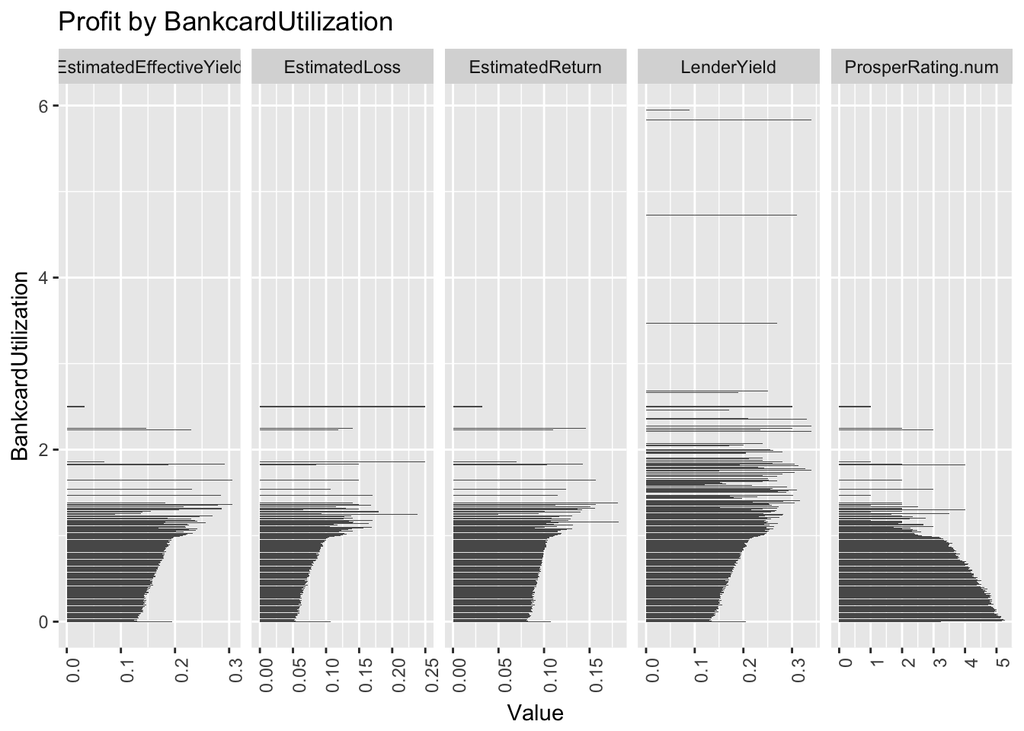

```r
subset <- c("EstimatedReturn", "EstimatedEffectiveYield", "EstimatedLoss", "LenderYield", "ProsperRating.num","BankcardUtilization")

plot_data <- data[subset] %>%
  group_by(BankcardUtilization) %>%
  summarize_all(funs(mean(., na.rm = TRUE))) %>%
  gather(Measure, Value, -BankcardUtilization)

ggplot(plot_data, aes(x = BankcardUtilization, y=Value)) +
  geom_bar(stat = "identity") +
  labs(title = "Profit by BankcardUtilization") +
  facet_grid(~Measure, scales="free") +
  coord_flip() +
  theme(axis.text.x = element_text(angle = 90, hjust = 1))
```

`TotalTrades`

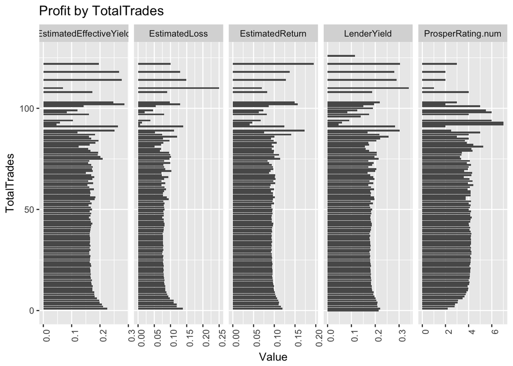

```r
subset <- c("EstimatedReturn", "EstimatedEffectiveYield", "EstimatedLoss", "LenderYield", "ProsperRating.num","TotalTrades")

plot_data <- data[subset] %>%
  group_by(TotalTrades) %>%
  summarize_all(funs(mean(., na.rm = TRUE))) %>%
  gather(Measure, Value, -TotalTrades)

ggplot(plot_data, aes(x = TotalTrades, y=Value)) +
  geom_bar(stat = "identity") +
  labs(title = "Profit by TotalTrades") +
  facet_grid(~Measure, scales="free") +
  coord_flip() +
  theme(axis.text.x = element_text(angle = 90, hjust = 1))
```

`DebtToIncomeRatio`

[figure not shown]

```r
subset <- c("EstimatedReturn", "EstimatedEffectiveYield", "EstimatedLoss", "LenderYield", "ProsperRating.num","DebtToIncomeRatio")

plot_data <- data[subset] %>%
  group_by(DebtToIncomeRatio) %>%
  summarize_all(funs(mean(., na.rm = TRUE))) %>%
  gather(Measure, Value, -DebtToIncomeRatio)

ggplot(plot_data, aes(x = DebtToIncomeRatio, y=Value)) +
  geom_bar(stat = "identity") +
  labs(title = "Profit by DebtToIncomeRatio") +
  facet_grid(~Measure, scales="free") +
  coord_flip() +
  theme(axis.text.x = element_text(angle = 90, hjust = 1))
```

`IncomeVerifiable`

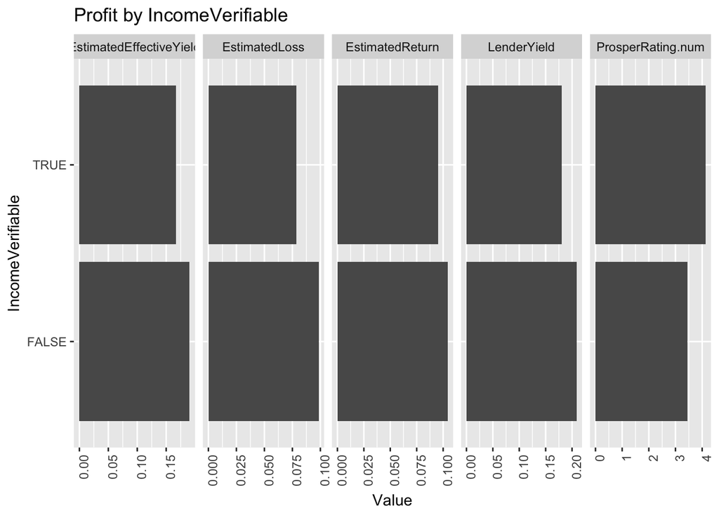

```r
subset <- c("EstimatedReturn", "EstimatedEffectiveYield", "EstimatedLoss", "LenderYield", "ProsperRating.num","IncomeVerifiable")

plot_data <- data[subset] %>%
  group_by(IncomeVerifiable) %>%
  summarize_all(funs(mean(., na.rm = TRUE))) %>%
  gather(Measure, Value, -IncomeVerifiable)

ggplot(plot_data, aes(x = IncomeVerifiable, y=Value)) +
  geom_bar(stat = "identity") +
  labs(title = "Profit by IncomeVerifiable") +
  facet_grid(~Measure, scales="free") +
  coord_flip() +
  theme(axis.text.x = element_text(angle = 90, hjust = 1))
```

`TotalProsperLoans`

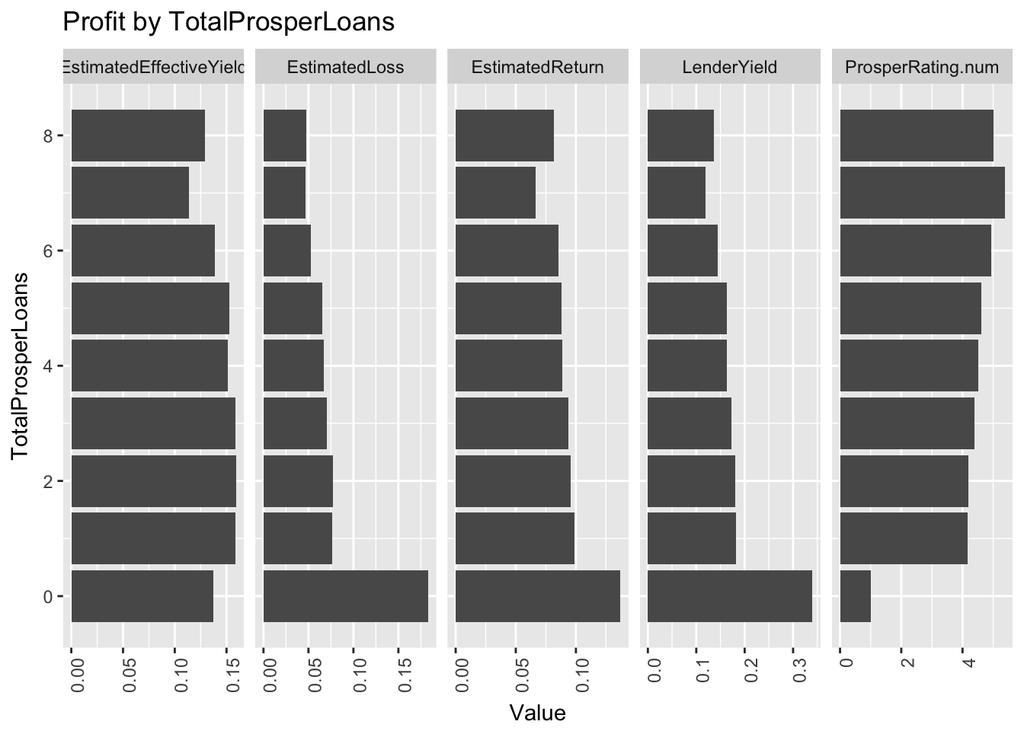

```r
subset <- c("EstimatedReturn", "EstimatedEffectiveYield", "EstimatedLoss", "LenderYield", "ProsperRating.num","TotalProsperLoans")

plot_data <- data[subset] %>%
  group_by(TotalProsperLoans) %>%
  summarize_all(funs(mean(., na.rm = TRUE))) %>%
  gather(Measure, Value, -TotalProsperLoans)

ggplot(plot_data, aes(x = TotalProsperLoans, y=Value)) +
  geom_bar(stat = "identity") +
  labs(title = "Profit by TotalProsperLoans") +
  facet_grid(~Measure, scales="free") +
  coord_flip() +
  theme(axis.text.x = element_text(angle = 90, hjust = 1))
```

`LoanOriginationQuarter`

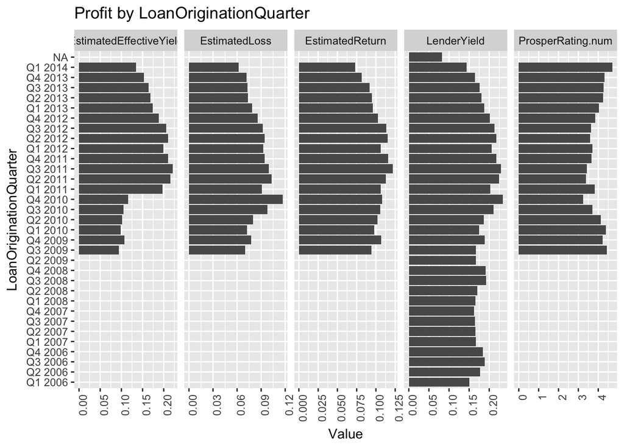

```r
subset <- c("EstimatedReturn", "EstimatedEffectiveYield", "EstimatedLoss", "LenderYield", "ProsperRating.num","LoanOriginationQuarter")

plot_data <- data[subset] %>%
  group_by(LoanOriginationQuarter) %>%
  summarize_all(funs(mean(., na.rm = TRUE))) %>%
  gather(Measure, Value, -LoanOriginationQuarter)

ggplot(plot_data, aes(x = LoanOriginationQuarter, y=Value)) +
  geom_bar(stat = "identity") +
  labs(title = "Profit by LoanOriginationQuarter") +
  facet_grid(~Measure, scales="free") +
  coord_flip() +
  theme(axis.text.x = element_text(angle = 90, hjust = 1))
```

Ultimately, without knowing how the loans ultimately panned out, it is a bit difficult to use this data to make future predictions.